# Flow Duration Curve

Worked Example 6.1

# Loading the Data

In this example we are going to use river flow data from the river Ngaruroro which is part of the `international` dataset in the package **hydroDrought**. This dataset becomes accessible by loading the **hydroDrought** package.

Tobias: Currently the variable in the dataset is called *discharge* but we should consider using *flow* or *riverflow* for consistency. *river flow* (which a space in it) is not advisable as a variable name.

```r
library(hydroDrought)
ngaruroro <- filter(international, River == "Ngaruroro") %>%
  select(discharge) %>%
  unnest()
```

# Calculation of the FDC

The flow duration curve is constructed following the calculation steps as given in the right part of the table:

- The rank, $i$, of each value is calculated (using the `rank()` function), which means that if the list is sorted, the rank will be its position. Here the series is sorted in descending order and the $i^{th}$ largest value has rank $i$ (i.e. the largest value has rank 1).
- The exceedance frequency, $EF_{Q_i}$ is calculated as:
  $$EF_{Q_i} = \frac{i} {N}$$
  which gives an estimate of the empirical exceedance frequency of the $i^{th}$ largest event. $EF_{Q_i}$ designates here the observed frequency when the flow, $Q$, is larger than the flow value with rank $i$, $Q_i$ .

```r
exceedance_frequency <- function(flow)
{
  # current rank
  i <- rank(-flow, ties.method = "min", na.last = "keep")

  # largest rank in sample (= number of non-missing values)
  N <- length(na.omit(flow))

  # the exceedance frequency can be seen as the relative rank
  return(i / N)
}

ngaruroro <- ngaruroro %>%
  mutate(rank = rank(-discharge, ties.method = "min"),
         freq.exc = exceedance_frequency(discharge))
```

Table 5.1 Calculation of a daily flow duration curve for River Ngaruroro at Kuripapango, NZ

| Date | $Q$ in $m^3s^{-1}$ Flow | $i$ Rank | $EF_Q$ Exceedance Frequency |
| --- | --- | --- | --- |
| 1963-09-20 | 30.512 | 1573 | 0.117 |
| 1963-09-21 | 52.858 | 522 | 0.039 |
| 1963-09-22 | 43.749 | 776 | 0.058 |
| 1963-09-23 | 37.353 | 1055 | 0.079 |
| 1963-09-24 | 32.349 | 1396 | 0.104 |
| 1963-09-25 | 29.001 | 1718 | 0.128 |
| 1963-09-26 | 25.341 | 2205 | 0.165 |

# Tabulation of the FDC

- Corresponding values of riverflow ($Q$ in m<sup>3</sup>s<sup>-1</sup>) and exceedance frequency ($EF_{Q_i}$ in %) are tabulated.

  Tobias: Tabulation was done implicitly in the sections before.
- The two columns are sorted by $EF_{Q_i}$.

  Tobias: Sorting is not required. I suggest to delete the section “Tabulation of the FDC” entirely.

# Plot of the FDC

The sorted table columns are then plotted (Figure 5.2). The ordinate axis is here logarithmic.

Tobias: I suggest to label the y-axis with “Flow percentile” (or more general “Flow quantile”).

Figure 5.2 Flow duration curve for River Ngaruroro at Kuripapango, NZ.

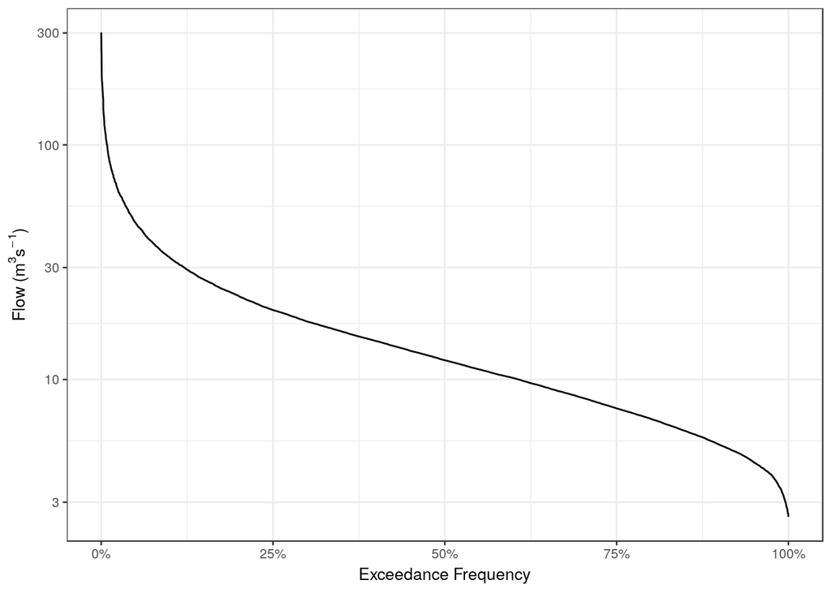

```r
ggplot(ngaruroro, aes(x = freq.exc, y = discharge)) +
  geom_line() +
  scale_y_log10() +
  scale_x_continuous(labels = percent_format(accuracy = 1)) +
  labs(x = "Exceedance Frequency",
       y = expression(paste("Flow (", m^{3}, s^{-1}, ")")))
```

# Selected exceedance values

Values for a particular frequency, for example the 90-percentile ($Q_{90}$), can be obtained as the value of $Q$ corresponding to the largest value of $EF_{Q_i}$ that is less than or equal to the value of $EF_{Q_i}$ sought for. A sample of corresponding values in this range is shown in Table 5.2, and the 90-percentile flow value is taken as 5.269 m<sup>3</sup>s<sup>-1</sup>. Alternatively, in case of large differences between successive values, a linear interpolation can be used.

Table 5.2 An extract of values corresponding to $Q_{90}$.

| Date | $Q$ in ${m^3s^{-1}}$ Flow | $i$ Rank | $EF_Q$ Exceedance Frequency |
| --- | --- | --- | --- |
| 1973-01-20 | 5.269 | 12063 | 0.89996 |
| 1995-02-02 | 5.268 | 12064 | 0.90003 |
| 1997-02-10 | 5.268 | 12064 | 0.90003 |
| 1989-03-25 | 5.265 | 12066 | 0.90018 |

The function `lfquantile()` calculates low-flow/riverflow quantiles directly. The exact (interpolated) values for $Q_{95}$, $Q_{90}$ and $Q_{80}$ would be:

Tobias: I’ve written a small wrapper function around `base::quantile()` to circumvent the naming problem and the transformation into non-exceedande frequencies.

```r
lfquantile(ngaruroro$discharge, exc.freq = c(0.95, 0.9, 0.8))
```

```
##    Q95    Q90    Q80
## 4.4303 5.2683 6.8012
```